# Modelo de Clasificación Binaria para la Predicción de Bancarrota Empresarial a partir de Estados Financieros: Dataset Taiwan Economic Journal

After-tax Net Profit Growth Rate

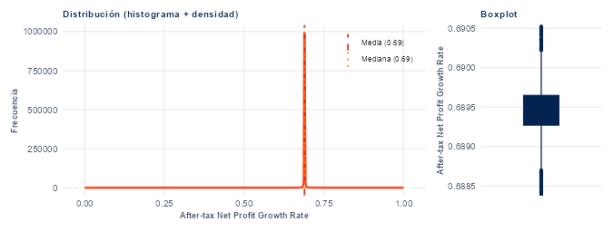

El histograma de **After-tax Net Profit Growth Rate** muestra un marcado sesgo a la izquierda (asimetría negativa), con una media de **68.92%** y una mediana de **68.94%**. La curtosis observada de **1438.63** indica una concentración notable de observaciones alrededor de la zona central, acompañada por la presencia de valores atípicos en las colas. Esta morfología sugiere una alta homogeneidad en el grueso de las empresas analizadas, pero con comportamientos extremos puntuales a monitorear en la etapa de preprocesamiento.

Regular Net Profit Growth Rate

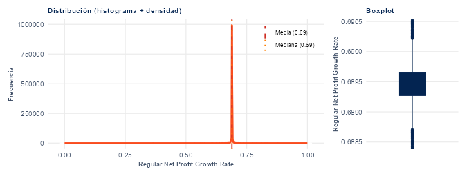

El histograma de **Regular Net Profit Growth Rate** muestra un marcado sesgo a la izquierda (asimetría negativa), con una media de **68.92%** y una mediana de **68.94%**. La curtosis observada de **1422.02** indica una concentración notable de observaciones alrededor de la zona central, acompañada por la presencia de valores atípicos en las colas. Esta morfología sugiere una alta homogeneidad en el grueso de las empresas analizadas, pero con comportamientos extremos puntuales a monitorear en la etapa de preprocesamiento.

Continuous Net Profit Growth Rate

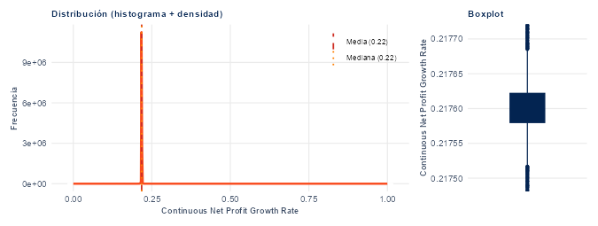

El histograma de **Continuous Net Profit Growth Rate** muestra un marcado sesgo a la derecha (asimetría positiva), con una media de **21.77%** y una mediana de **21.76%**. La curtosis observada de **4358.92** indica una concentración notable de observaciones alrededor de la zona central, acompañada por la presencia de valores atípicos en las colas. Esta morfología sugiere una alta homogeneidad en el grueso de las empresas analizadas, pero con comportamientos extremos puntuales a monitorear en la etapa de preprocesamiento.

Total Asset Growth Rate

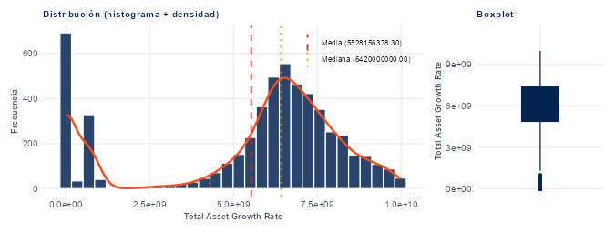

Net Value Growth Rate

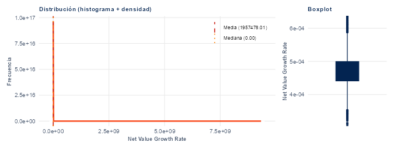

El histograma de **Net Value Growth Rate** muestra un marcado sesgo a la derecha (asimetría positiva), con una media de **195747800.66%** y una mediana de **0.05%**. La curtosis observada de **5236.67** indica una concentración notable de observaciones alrededor de la zona central, acompañada por la presencia de valores atípicos en las colas. Esta morfología sugiere una alta homogeneidad en el grueso de las empresas analizadas, pero con comportamientos extremos puntuales a monitorear en la etapa de preprocesamiento.

Total Asset Return Growth Rate Ratio

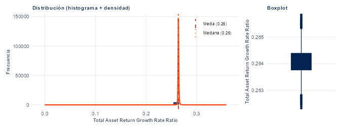

El histograma de **Total Asset Return Growth Rate Ratio** muestra un marcado sesgo a la izquierda (asimetría negativa), con una media de **26.41%** y una mediana de **26.41%**. La curtosis observada de **3341.97** indica una concentración notable de observaciones alrededor de la zona central, acompañada por la presencia de valores atípicos en las colas. Esta morfología sugiere una alta homogeneidad en el grueso de las empresas analizadas, pero con comportamientos extremos puntuales a monitorear en la etapa de preprocesamiento.

Cash Reinvestment %

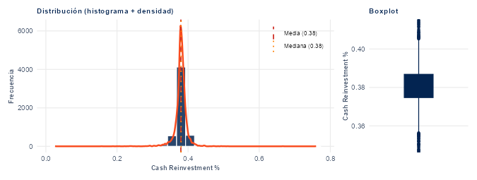

El histograma de **Cash Reinvestment %** muestra un marcado sesgo a la izquierda (asimetría negativa), con una media de **37.96%** y una mediana de **38.03%**. La curtosis observada de **72.47** indica una concentración notable de observaciones alrededor de la zona central, acompañada por la presencia de valores atípicos en las colas. Esta morfología sugiere una alta homogeneidad en el grueso de las empresas analizadas, pero con comportamientos extremos puntuales a monitorear en la etapa de preprocesamiento.

Current Ratio

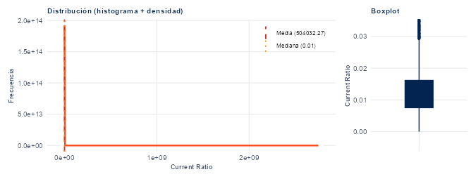

El histograma de **Current Ratio** muestra un marcado sesgo a la derecha (asimetría positiva), con una media de **504032.2733 ratio** y una mediana de **0.0106 ratio**. La curtosis observada de **5456.00** indica una concentración notable de observaciones alrededor de la zona central, acompañada por la presencia de valores atípicos en las colas. Esta morfología sugiere una alta homogeneidad en el grueso de las empresas analizadas, pero con comportamientos extremos puntuales a monitorear en la etapa de preprocesamiento.

Quick Ratio

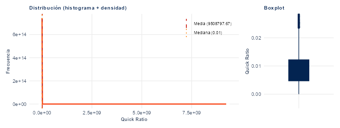

El histograma de **Quick Ratio** muestra un marcado sesgo a la derecha (asimetría positiva), con una media de **9508797.6651 ratio** y una mediana de **0.0074 ratio**. La curtosis observada de **938.53** indica una concentración notable de observaciones alrededor de la zona central, acompañada por la presencia de valores atípicos en las colas. Esta morfología sugiere una alta homogeneidad en el grueso de las empresas analizadas, pero con comportamientos extremos puntuales a monitorear en la etapa de preprocesamiento.

Interest Expense Ratio

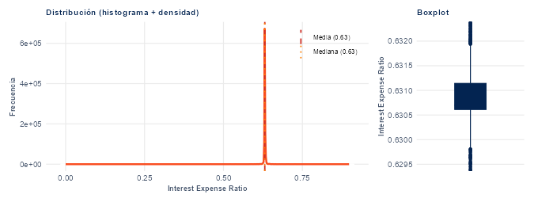

El histograma de **Interest Expense Ratio** muestra un marcado sesgo a la izquierda (asimetría negativa), con una media de **63.10%** y una mediana de **63.07%**. La curtosis observada de **1974.83** indica una concentración notable de observaciones alrededor de la zona central, acompañada por la presencia de valores atípicos en las colas. Esta morfología sugiere una alta homogeneidad en el grueso de las empresas analizadas, pero con comportamientos extremos puntuales a monitorear en la etapa de preprocesamiento.

Total debt/Total net worth

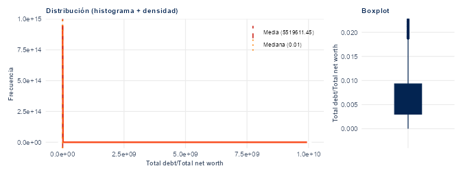

El histograma de **Total debt/Total net worth** muestra un marcado sesgo a la derecha (asimetría positiva), con una media de **5519611.4450 ratio** y una mediana de **0.0055 ratio**. La curtosis observada de **1878.29** indica una concentración notable de observaciones alrededor de la zona central, acompañada por la presencia de valores atípicos en las colas. Esta morfología sugiere una alta homogeneidad en el grueso de las empresas analizadas, pero con comportamientos extremos puntuales a monitorear en la etapa de preprocesamiento.

Debt ratio %

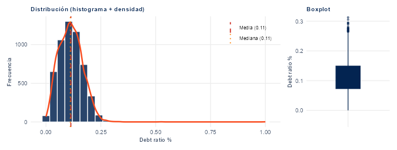

El histograma de **Debt ratio %** muestra un marcado sesgo a la derecha (asimetría positiva), con una media de **11.35%** y una mediana de **11.12%**. La curtosis observada de **13.04** indica una concentración notable de observaciones alrededor de la zona central, acompañada por la presencia de valores atípicos en las colas. Esta morfología sugiere una alta homogeneidad en el grueso de las empresas analizadas, pero con comportamientos extremos puntuales a monitorear en la etapa de preprocesamiento.

Net worth/Assets

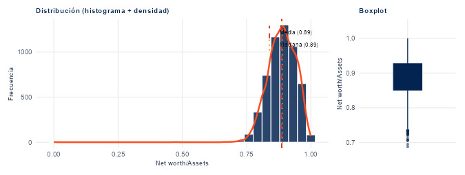

El histograma de **Net worth/Assets** muestra un marcado sesgo a la izquierda (asimetría negativa), con una media de **88.65%** y una mediana de **88.88%**. La curtosis observada de **13.04** indica una concentración notable de observaciones alrededor de la zona central, acompañada por la presencia de valores atípicos en las colas. Esta morfología sugiere una alta homogeneidad en el grueso de las empresas analizadas, pero con comportamientos extremos puntuales a monitorear en la etapa de preprocesamiento.

Long-term fund suitability ratio (A)

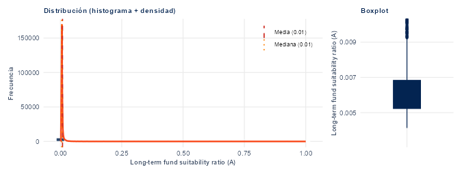

El histograma de **Long-term fund suitability ratio (A)** muestra un marcado sesgo a la derecha (asimetría positiva), con una media de **0.0085 ratio** y una mediana de **0.0056 ratio**. La curtosis observada de **848.01** indica una concentración notable de observaciones alrededor de la zona central, acompañada por la presencia de valores atípicos en las colas. Esta morfología sugiere una alta homogeneidad en el grueso de las empresas analizadas, pero con comportamientos extremos puntuales a monitorear en la etapa de preprocesamiento.

Borrowing dependency

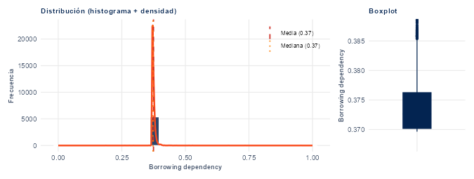

El histograma de **Borrowing dependency** muestra un marcado sesgo a la derecha (asimetría positiva), con una media de **0.3746 ratio** y una mediana de **0.3726 ratio**. La curtosis observada de **853.16** indica una concentración notable de observaciones alrededor de la zona central, acompañada por la presencia de valores atípicos en las colas. Esta morfología sugiere una alta homogeneidad en el grueso de las empresas analizadas, pero con comportamientos extremos puntuales a monitorear en la etapa de preprocesamiento.

Contingent liabilities/Net worth

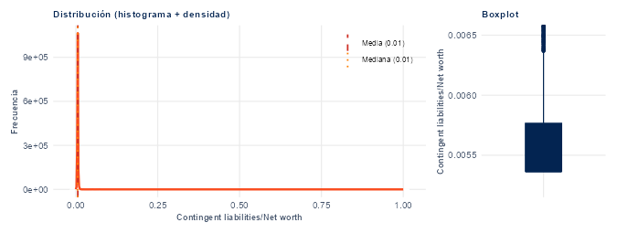

El histograma de **Contingent liabilities/Net worth** muestra un marcado sesgo a la derecha (asimetría positiva), con una media de **0.0060 ratio** y una mediana de **0.0054 ratio**. La curtosis observada de **5214.29** indica una concentración notable de observaciones alrededor de la zona central, acompañada por la presencia de valores atípicos en las colas. Esta morfología sugiere una alta homogeneidad en el grueso de las empresas analizadas, pero con comportamientos extremos puntuales a monitorear en la etapa de preprocesamiento.

Operating profit/Paid-in capital

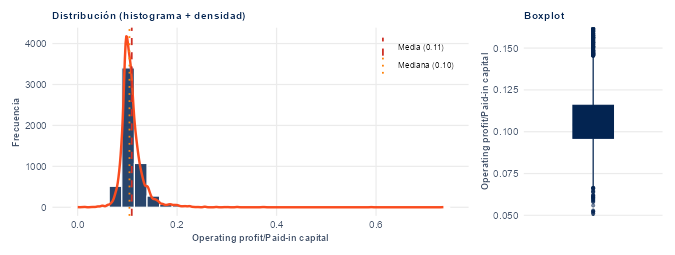

El histograma de **Operating profit/Paid-in capital** muestra un marcado sesgo a la derecha (asimetría positiva), con una media de **10.88%** y una mediana de **10.42%**. La curtosis observada de **94.53** indica una concentración notable de observaciones alrededor de la zona central, acompañada por la presencia de valores atípicos en las colas. Esta morfología sugiere una alta homogeneidad en el grueso de las empresas analizadas, pero con comportamientos extremos puntuales a monitorear en la etapa de preprocesamiento.

Net profit before tax/Paid-in capital

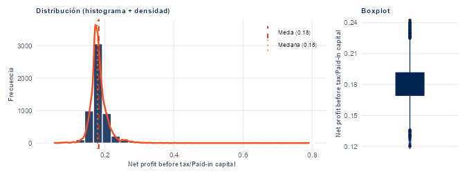

El histograma de **Net profit before tax/Paid-in capital** muestra un marcado sesgo a la derecha (asimetría positiva), con una media de **18.25%** y una mediana de **17.86%**. La curtosis observada de **69.94** indica una concentración notable de observaciones alrededor de la zona central, acompañada por la presencia de valores atípicos en las colas. Esta morfología sugiere una alta homogeneidad en el grueso de las empresas analizadas, pero con comportamientos extremos puntuales a monitorear en la etapa de preprocesamiento.

Inventory and accounts receivable/Net value

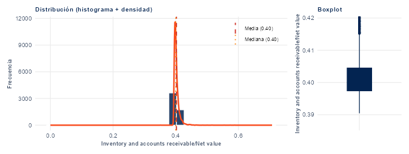

Total Asset Turnover

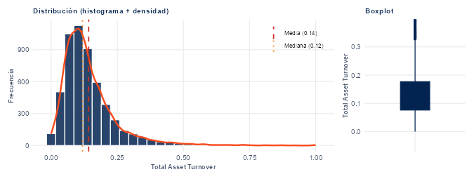

El histograma de **Total Asset Turnover** muestra un marcado sesgo a la derecha (asimetría positiva), con una media de **0.1418 ratio** y una mediana de **0.1184 ratio**. La curtosis observada de **9.63** indica una concentración notable de observaciones alrededor de la zona central, acompañada por la presencia de valores atípicos en las colas. Esta morfología sugiere una alta homogeneidad en el grueso de las empresas analizadas, pero con comportamientos extremos puntuales a monitorear en la etapa de preprocesamiento.

Accounts Receivable Turnover

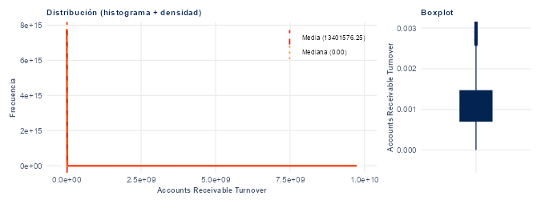

El histograma de **Accounts Receivable Turnover** muestra un marcado sesgo a la derecha (asimetría positiva), con una media de **13401576.2485 ratio** y una mediana de **0.0010 ratio**. La curtosis observada de **737.92** indica una concentración notable de observaciones alrededor de la zona central, acompañada por la presencia de valores atípicos en las colas. Esta morfología sugiere una alta homogeneidad en el grueso de las empresas analizadas, pero con comportamientos extremos puntuales a monitorear en la etapa de preprocesamiento.

Average Collection Days

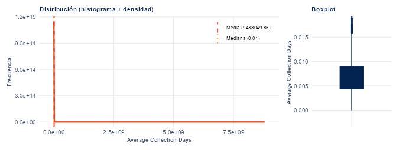

El histograma de **Average Collection Days** muestra un marcado sesgo a la derecha (asimetría positiva), con una media de **9438049.8612 días** y una mediana de **0.0066 días**. La curtosis observada de **953.52** indica una concentración notable de observaciones alrededor de la zona central, acompañada por la presencia de valores atípicos en las colas. Esta morfología sugiere una alta homogeneidad en el grueso de las empresas analizadas, pero con comportamientos extremos puntuales a monitorear en la etapa de preprocesamiento.

Inventory Turnover Rate (times)

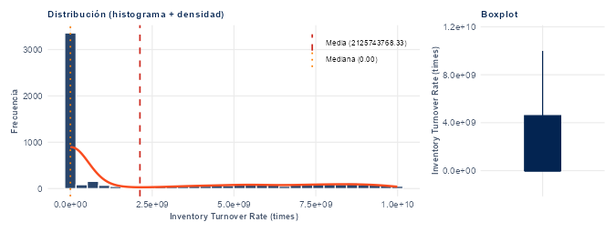

Fixed Assets Turnover Frequency

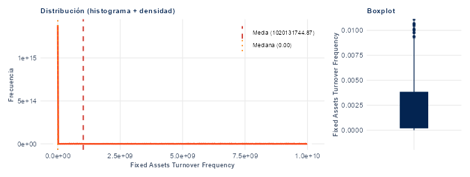

El histograma de **Fixed Assets Turnover Frequency** muestra un marcado sesgo a la derecha (asimetría positiva), con una media de **1020131744.8699 ratio** y una mediana de **0.0006 ratio**. La curtosis observada de **3.98** indica una concentración notable de observaciones alrededor de la zona central, acompañada por la presencia de valores atípicos en las colas. Esta morfología sugiere una alta homogeneidad en el grueso de las empresas analizadas, pero con comportamientos extremos puntuales a monitorear en la etapa de preprocesamiento.

Net Worth Turnover Rate (times)

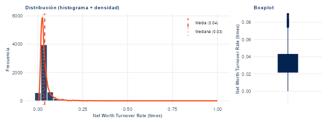

El histograma de **Net Worth Turnover Rate (times)** muestra un marcado sesgo a la derecha (asimetría positiva), con una media de **0.0386 ratio** y una mediana de **0.0295 ratio**. La curtosis observada de **153.88** indica una concentración notable de observaciones alrededor de la zona central, acompañada por la presencia de valores atípicos en las colas. Esta morfología sugiere una alta homogeneidad en el grueso de las empresas analizadas, pero con comportamientos extremos puntuales a monitorear en la etapa de preprocesamiento.

Revenue per person

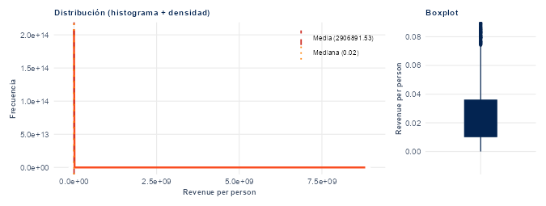

El histograma de **Revenue per person** muestra un marcado sesgo a la derecha (asimetría positiva), con una media de **2906891.5313 Yuan ¥/persona** y una mediana de **0.0186 Yuan ¥/persona**. La curtosis observada de **2856.77** indica una concentración notable de observaciones alrededor de la zona central, acompañada por la presencia de valores atípicos en las colas. Esta morfología sugiere una alta homogeneidad en el grueso de las empresas analizadas, pero con comportamientos extremos puntuales a monitorear en la etapa de preprocesamiento.

Operating profit per person

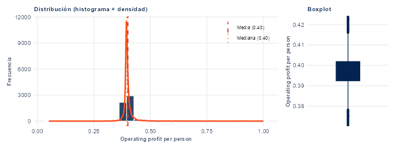

El histograma de **Operating profit per person** muestra un marcado sesgo a la derecha (asimetría positiva), con una media de **0.4007 Yuan ¥/persona** y una mediana de **0.3959 Yuan ¥/persona**. La curtosis observada de **120.00** indica una concentración notable de observaciones alrededor de la zona central, acompañada por la presencia de valores atípicos en las colas. Esta morfología sugiere una alta homogeneidad en el grueso de las empresas analizadas, pero con comportamientos extremos puntuales a monitorear en la etapa de preprocesamiento.

Allocation rate per person

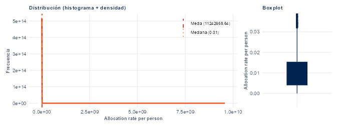

El histograma de **Allocation rate per person** muestra un marcado sesgo a la derecha (asimetría positiva), con una media de **11242668.6376 Yuan ¥/persona** y una mediana de **0.0079 Yuan ¥/persona**. La curtosis observada de **775.95** indica una concentración notable de observaciones alrededor de la zona central, acompañada por la presencia de valores atípicos en las colas. Esta morfología sugiere una alta homogeneidad en el grueso de las empresas analizadas, pero con comportamientos extremos puntuales a monitorear en la etapa de preprocesamiento.

Working Capital to Total Assets

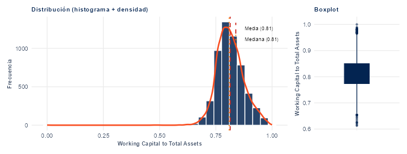

El histograma de **Working Capital to Total Assets** muestra una distribución relativamente simétrica, con una media de **0.8137 ratio** y una mediana de **0.8093 ratio**. La curtosis observada de **6.62** indica una concentración notable de observaciones alrededor de la zona central, acompañada por la presencia de valores atípicos en las colas. Esta morfología sugiere una alta homogeneidad en el grueso de las empresas analizadas, pero con comportamientos extremos puntuales a monitorear en la etapa de preprocesamiento.

Quick Assets/Total Assets

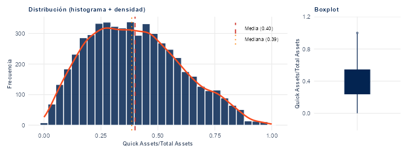

Current Assets/Total Assets

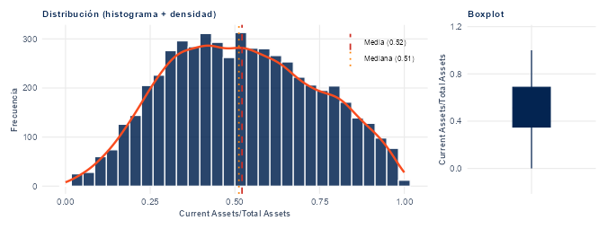

Cash/Total Assets

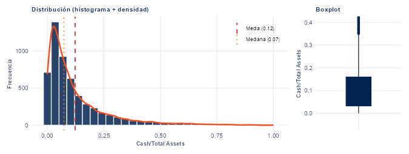

El histograma de **Cash/Total Assets** muestra un marcado sesgo a la derecha (asimetría positiva), con una media de **0.1231 ratio** y una mediana de **0.0734 ratio**. La curtosis observada de **5.99** indica una concentración notable de observaciones alrededor de la zona central, acompañada por la presencia de valores atípicos en las colas. Esta morfología sugiere una alta homogeneidad en el grueso de las empresas analizadas, pero con comportamientos extremos puntuales a monitorear en la etapa de preprocesamiento.

Quick Assets/Current Liability

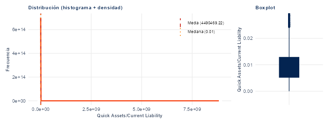

El histograma de **Quick Assets/Current Liability** muestra un marcado sesgo a la derecha (asimetría positiva), con una media de **4490469.2200 ratio** y una mediana de **0.0079 ratio**. La curtosis observada de **1845.11** indica una concentración notable de observaciones alrededor de la zona central, acompañada por la presencia de valores atípicos en las colas. Esta morfología sugiere una alta homogeneidad en el grueso de las empresas analizadas, pero con comportamientos extremos puntuales a monitorear en la etapa de preprocesamiento.

Cash/Current Liability

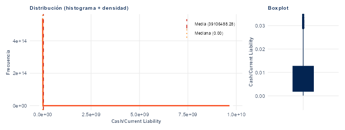

El histograma de **Cash/Current Liability** muestra un marcado sesgo a la derecha (asimetría positiva), con una media de **39106488.2830 ratio** y una mediana de **0.0048 ratio**. La curtosis observada de **217.59** indica una concentración notable de observaciones alrededor de la zona central, acompañada por la presencia de valores atípicos en las colas. Esta morfología sugiere una alta homogeneidad en el grueso de las empresas analizadas, pero con comportamientos extremos puntuales a monitorear en la etapa de preprocesamiento.

Current Liability to Assets

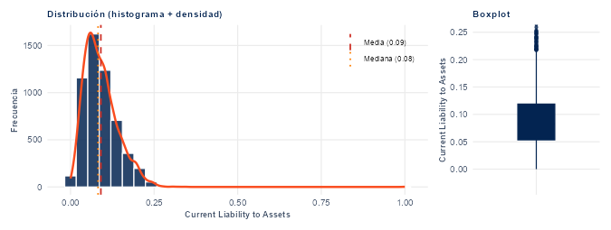

El histograma de **Current Liability to Assets** muestra un marcado sesgo a la derecha (asimetría positiva), con una media de **9.08%** y una mediana de **8.23%**. La curtosis observada de **18.91** indica una concentración notable de observaciones alrededor de la zona central, acompañada por la presencia de valores atípicos en las colas. Esta morfología sugiere una alta homogeneidad en el grueso de las empresas analizadas, pero con comportamientos extremos puntuales a monitorear en la etapa de preprocesamiento.

Operating Funds to Liability

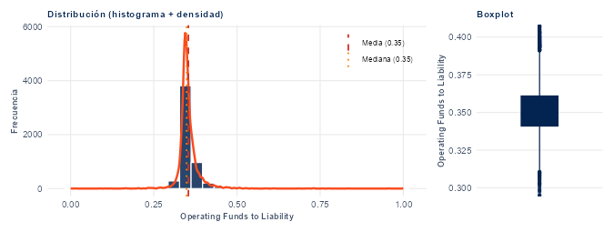

El histograma de **Operating Funds to Liability** muestra un marcado sesgo a la derecha (asimetría positiva), con una media de **0.3539 ratio** y una mediana de **0.3485 ratio**. La curtosis observada de **65.46** indica una concentración notable de observaciones alrededor de la zona central, acompañada por la presencia de valores atípicos en las colas. Esta morfología sugiere una alta homogeneidad en el grueso de las empresas analizadas, pero con comportamientos extremos puntuales a monitorear en la etapa de preprocesamiento.

Inventory/Working Capital

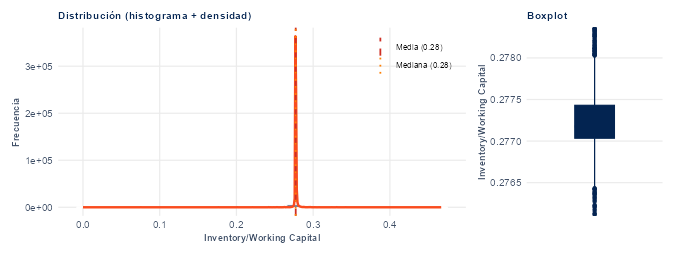

El histograma de **Inventory/Working Capital** muestra un marcado sesgo a la izquierda (asimetría negativa), con una media de **0.2773 ratio** y una mediana de **0.2772 ratio**. La curtosis observada de **1139.25** indica una concentración notable de observaciones alrededor de la zona central, acompañada por la presencia de valores atípicos en las colas. Esta morfología sugiere una alta homogeneidad en el grueso de las empresas analizadas, pero con comportamientos extremos puntuales a monitorear en la etapa de preprocesamiento.

Inventory/Current Liability

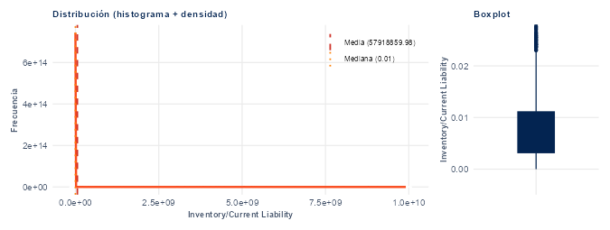

El histograma de **Inventory/Current Liability** muestra un marcado sesgo a la derecha (asimetría positiva), con una media de **57918859.9798 ratio** y una mediana de **0.0065 ratio**. La curtosis observada de **147.33** indica una concentración notable de observaciones alrededor de la zona central, acompañada por la presencia de valores atípicos en las colas. Esta morfología sugiere una alta homogeneidad en el grueso de las empresas analizadas, pero con comportamientos extremos puntuales a monitorear en la etapa de preprocesamiento.

Current Liabilities/Liability

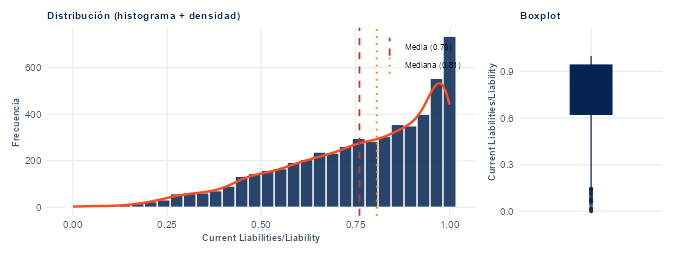

Working Capital/Equity

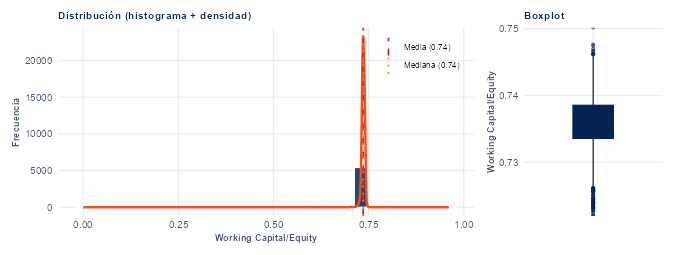

El histograma de **Working Capital/Equity** muestra un marcado sesgo a la izquierda (asimetría negativa), con una media de **0.7357 ratio** y una mediana de **0.7360 ratio**. La curtosis observada de **2434.02** indica una concentración notable de observaciones alrededor de la zona central, acompañada por la presencia de valores atípicos en las colas. Esta morfología sugiere una alta homogeneidad en el grueso de las empresas analizadas, pero con comportamientos extremos puntuales a monitorear en la etapa de preprocesamiento.

Current Liabilities/Equity

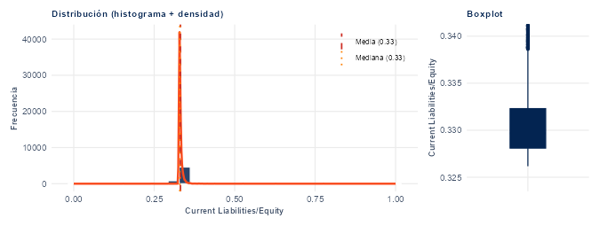

El histograma de **Current Liabilities/Equity** muestra un marcado sesgo a la derecha (asimetría positiva), con una media de **0.3314 ratio** y una mediana de **0.3297 ratio**. La curtosis observada de **1133.32** indica una concentración notable de observaciones alrededor de la zona central, acompañada por la presencia de valores atípicos en las colas. Esta morfología sugiere una alta homogeneidad en el grueso de las empresas analizadas, pero con comportamientos extremos puntuales a monitorear en la etapa de preprocesamiento.

Long-term Liability to Current Assets

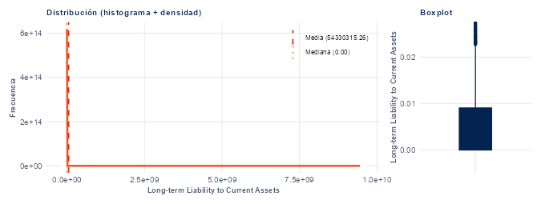

El histograma de **Long-term Liability to Current Assets** muestra un marcado sesgo a la derecha (asimetría positiva), con una media de **54330315.2566 ratio** y una mediana de **0.0020 ratio**. La curtosis observada de **160.99** indica una concentración notable de observaciones alrededor de la zona central, acompañada por la presencia de valores atípicos en las colas. Esta morfología sugiere una alta homogeneidad en el grueso de las empresas analizadas, pero con comportamientos extremos puntuales a monitorear en la etapa de preprocesamiento.

Retained Earnings to Total Assets

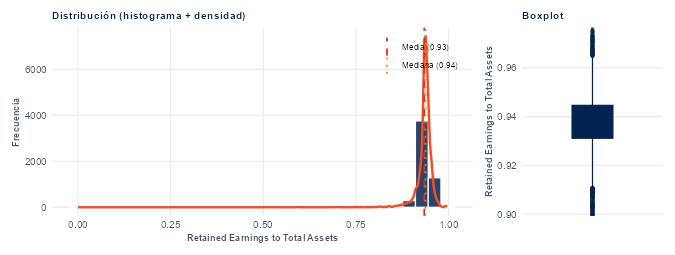

El histograma de **Retained Earnings to Total Assets** muestra un marcado sesgo a la izquierda (asimetría negativa), con una media de **0.9346 ratio** y una mediana de **0.9377 ratio**. La curtosis observada de **329.01** indica una concentración notable de observaciones alrededor de la zona central, acompañada por la presencia de valores atípicos en las colas. Esta morfología sugiere una alta homogeneidad en el grueso de las empresas analizadas, pero con comportamientos extremos puntuales a monitorear en la etapa de preprocesamiento.

Total income/Total expense

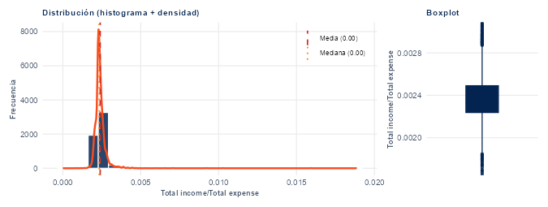

El histograma de **Total income/Total expense** muestra un marcado sesgo a la derecha (asimetría positiva), con una media de **0.0024 ratio** y una mediana de **0.0023 ratio**. La curtosis observada de **430.51** indica una concentración notable de observaciones alrededor de la zona central, acompañada por la presencia de valores atípicos en las colas. Esta morfología sugiere una alta homogeneidad en el grueso de las empresas analizadas, pero con comportamientos extremos puntuales a monitorear en la etapa de preprocesamiento.

Total expense/Assets

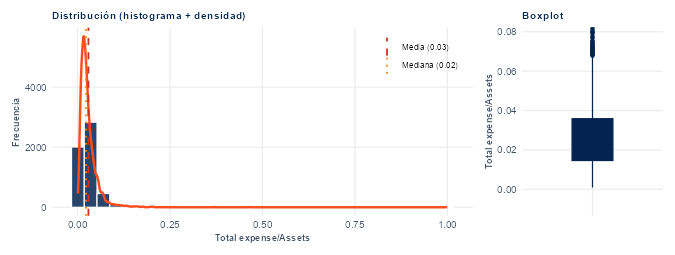

El histograma de **Total expense/Assets** muestra un marcado sesgo a la derecha (asimetría positiva), con una media de **2.93%** y una mediana de **2.27%**. La curtosis observada de **278.58** indica una concentración notable de observaciones alrededor de la zona central, acompañada por la presencia de valores atípicos en las colas. Esta morfología sugiere una alta homogeneidad en el grueso de las empresas analizadas, pero con comportamientos extremos puntuales a monitorear en la etapa de preprocesamiento.

Current Asset Turnover Rate

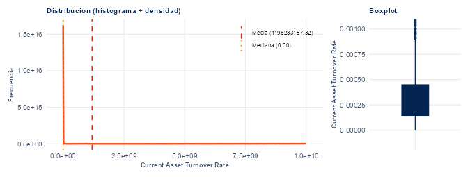

Quick Asset Turnover Rate

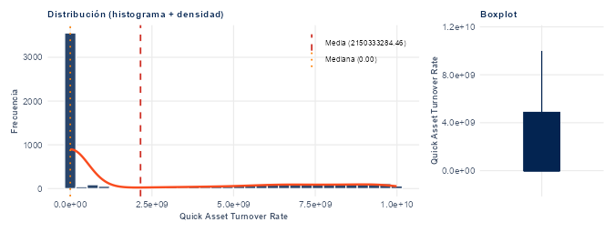

Working capitcal Turnover Rate

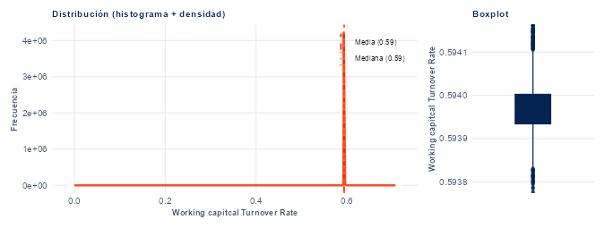

El histograma de **Working capitcal Turnover Rate** muestra un marcado sesgo a la izquierda (asimetría negativa), con una media de **0.5939 ratio** y una mediana de **0.5940 ratio**. La curtosis observada de **4654.13** indica una concentración notable de observaciones alrededor de la zona central, acompañada por la presencia de valores atípicos en las colas. Esta morfología sugiere una alta homogeneidad en el grueso de las empresas analizadas, pero con comportamientos extremos puntuales a monitorear en la etapa de preprocesamiento.

Cash Turnover Rate

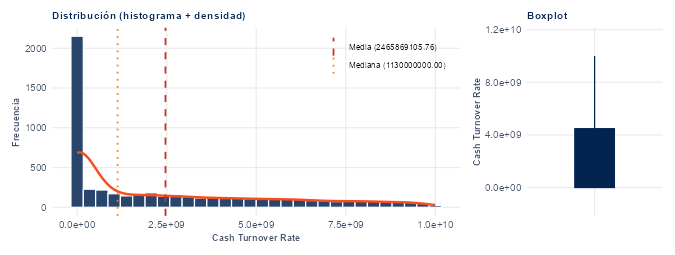

Cash Flow to Sales

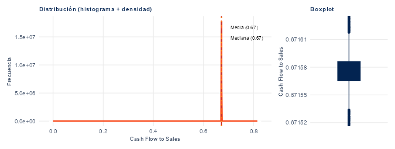

El histograma de **Cash Flow to Sales** muestra un marcado sesgo a la izquierda (asimetría negativa), con una media de **67.15%** y una mediana de **67.16%**. La curtosis observada de **4691.82** indica una concentración notable de observaciones alrededor de la zona central, acompañada por la presencia de valores atípicos en las colas. Esta morfología sugiere una alta homogeneidad en el grueso de las empresas analizadas, pero con comportamientos extremos puntuales a monitorear en la etapa de preprocesamiento.

Fixed Assets to Assets

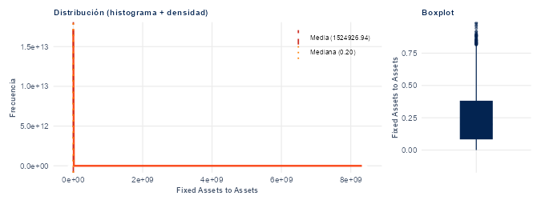

El histograma de **Fixed Assets to Assets** muestra un marcado sesgo a la derecha (asimetría positiva), con una media de **152492693.81%** y una mediana de **19.94%**. La curtosis observada de **5456.00** indica una concentración notable de observaciones alrededor de la zona central, acompañada por la presencia de valores atípicos en las colas. Esta morfología sugiere una alta homogeneidad en el grueso de las empresas analizadas, pero con comportamientos extremos puntuales a monitorear en la etapa de preprocesamiento.

Current Liability to Liability

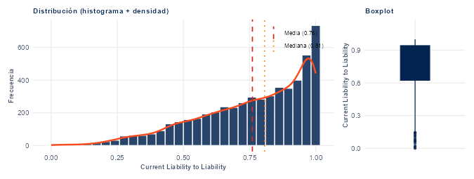

Current Liability to Equity

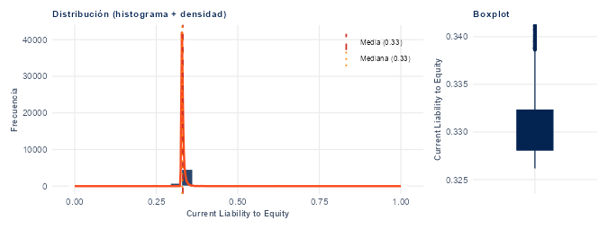

El histograma de **Current Liability to Equity** muestra un marcado sesgo a la derecha (asimetría positiva), con una media de **0.3314 ratio** y una mediana de **0.3297 ratio**. La curtosis observada de **1133.32** indica una concentración notable de observaciones alrededor de la zona central, acompañada por la presencia de valores atípicos en las colas. Esta morfología sugiere una alta homogeneidad en el grueso de las empresas analizadas, pero con comportamientos extremos puntuales a monitorear en la etapa de preprocesamiento.

Equity to Long-term Liability

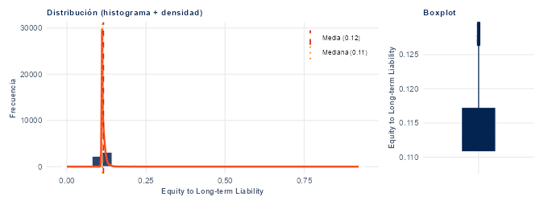

El histograma de **Equity to Long-term Liability** muestra un marcado sesgo a la derecha (asimetría positiva), con una media de **0.1156 ratio** y una mediana de **0.1124 ratio**. La curtosis observada de **1463.64** indica una concentración notable de observaciones alrededor de la zona central, acompañada por la presencia de valores atípicos en las colas. Esta morfología sugiere una alta homogeneidad en el grueso de las empresas analizadas, pero con comportamientos extremos puntuales a monitorear en la etapa de preprocesamiento.

Cash Flow to Total Assets

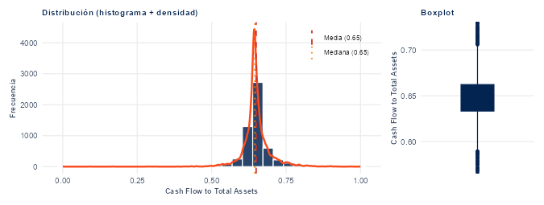

El histograma de **Cash Flow to Total Assets** muestra una distribución relativamente simétrica, con una media de **0.6494 ratio** y una mediana de **0.6452 ratio**. La curtosis observada de **18.50** indica una concentración notable de observaciones alrededor de la zona central, acompañada por la presencia de valores atípicos en las colas. Esta morfología sugiere una alta homogeneidad en el grueso de las empresas analizadas, pero con comportamientos extremos puntuales a monitorear en la etapa de preprocesamiento.

Cash Flow to Liability

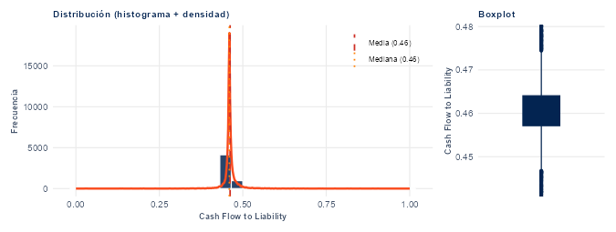

El histograma de **Cash Flow to Liability** muestra un marcado sesgo a la derecha (asimetría positiva), con una media de **0.4619 ratio** y una mediana de **0.4597 ratio**. La curtosis observada de **83.50** indica una concentración notable de observaciones alrededor de la zona central, acompañada por la presencia de valores atípicos en las colas. Esta morfología sugiere una alta homogeneidad en el grueso de las empresas analizadas, pero con comportamientos extremos puntuales a monitorear en la etapa de preprocesamiento.

CFO to Assets

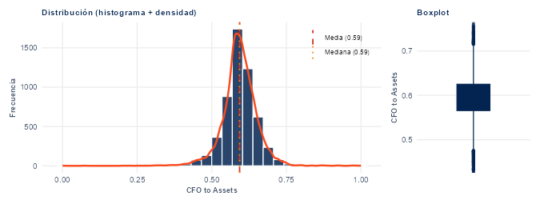

El histograma de **CFO to Assets** muestra una distribución relativamente simétrica, con una media de **59.34%** y una mediana de **59.32%**. La curtosis observada de **7.47** indica una concentración notable de observaciones alrededor de la zona central, acompañada por la presencia de valores atípicos en las colas. Esta morfología sugiere una alta homogeneidad en el grueso de las empresas analizadas, pero con comportamientos extremos puntuales a monitorear en la etapa de preprocesamiento.

Cash Flow to Equity

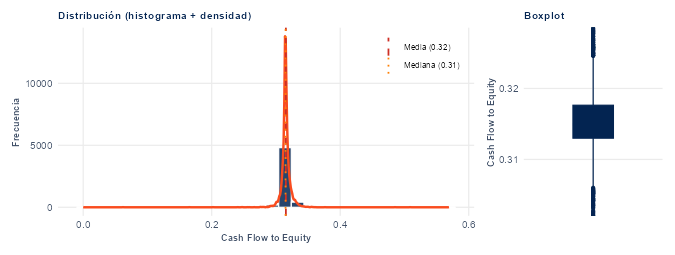

El histograma de **Cash Flow to Equity** muestra un marcado sesgo a la izquierda (asimetría negativa), con una media de **0.3154 ratio** y una mediana de **0.3149 ratio**. La curtosis observada de **314.78** indica una concentración notable de observaciones alrededor de la zona central, acompañada por la presencia de valores atípicos en las colas. Esta morfología sugiere una alta homogeneidad en el grueso de las empresas analizadas, pero con comportamientos extremos puntuales a monitorear en la etapa de preprocesamiento.

Current Liability to Current Assets

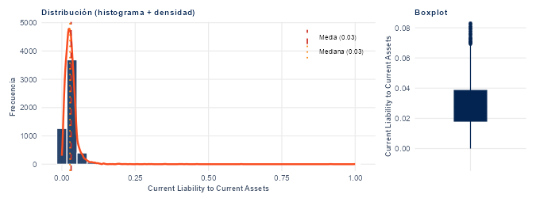

El histograma de **Current Liability to Current Assets** muestra un marcado sesgo a la derecha (asimetría positiva), con una media de **0.0316 ratio** y una mediana de **0.0277 ratio**. La curtosis observada de **346.37** indica una concentración notable de observaciones alrededor de la zona central, acompañada por la presencia de valores atípicos en las colas. Esta morfología sugiere una alta homogeneidad en el grueso de las empresas analizadas, pero con comportamientos extremos puntuales a monitorear en la etapa de preprocesamiento.

Net Income to Total Assets

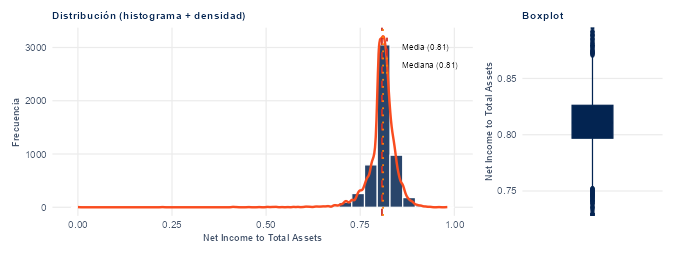

El histograma de **Net Income to Total Assets** muestra un marcado sesgo a la izquierda (asimetría negativa), con una media de **0.8077 ratio** y una mediana de **0.8107 ratio**. La curtosis observada de **49.73** indica una concentración notable de observaciones alrededor de la zona central, acompañada por la presencia de valores atípicos en las colas. Esta morfología sugiere una alta homogeneidad en el grueso de las empresas analizadas, pero con comportamientos extremos puntuales a monitorear en la etapa de preprocesamiento.

Total assets to GNP price

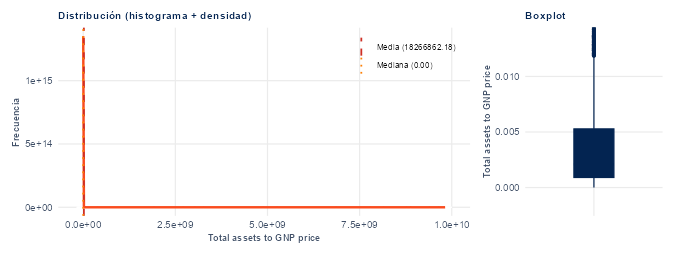

El histograma de **Total assets to GNP price** muestra un marcado sesgo a la derecha (asimetría positiva), con una media de **18266862.1788 ratio** y una mediana de **0.0021 ratio**. La curtosis observada de **512.27** indica una concentración notable de observaciones alrededor de la zona central, acompañada por la presencia de valores atípicos en las colas. Esta morfología sugiere una alta homogeneidad en el grueso de las empresas analizadas, pero con comportamientos extremos puntuales a monitorear en la etapa de preprocesamiento.